# Tidy Courses Proposal

Nils and Juliana

```r
library(tidyverse)
library(broom)
```

```r
coa_courses <- read_excel("data/coa-courses.xlsx")
coa_courses2 <- read_csv("data/coa_courses2.csv")
glimpse(coa_courses)
```

```
## Rows: 1,327
## Columns: 8
## $ Department        <chr> "AD", "AD", "AD", "AD", "AD", "AD", "AD", "AD", "AD"…
## $ CourseNumber      <chr> "1011", "1011", "1011", "1012", "1012", "1012", "101…
## $ CourseDivision    <chr> "ADS", "ADS", "ADS", "ADS", "ADS", "ADS", "AD HY", "…
## $ CourseName        <chr> "Introduction to Arts and Design", "Introduction to …
## $ Instructor        <chr> "Mancinelli, Isabel", "Mancinelli, Isabel", "Mancine…
## $ CourseDescription <chr> "This course is the fundamental course for students …
## $ ActiveFlag        <lgl> TRUE, TRUE, TRUE, TRUE, TRUE, TRUE, TRUE, TRUE, TRUE…
## $ Semester          <chr> "B18Q", "B19Q", "B20Q", "B20C", "B19B", "B18C", "B18…
```

```r
coa_courses <- coa_courses %>%
  mutate(Year = str_c(20, str_extract(Semester, "\\d{2}")),
         Term = str_sub(Semester, start = 4, end = 4),
         Level = str_extract(CourseDescription, pattern = "Level: Intermediate|Level: Introductory|Level: Advanced"),
         Prerequisites = str_extract(CourseDescription, pattern = "Prerequisites[^.]+"),
         Lab_Fee_Text = str_extract(CourseDescription, pattern = "(?<=Lab fee\\:|Lab Fee\\:|Lab fee \\$|Lab Fee \\$|Course fee\\:|Course Fee\\:|Course fee \\$)[^.]+"),
         Lab_Fee = str_detect(CourseDescription, pattern = "fee|Fee"),
         Class_Size_Text = str_extract(CourseDescription, pattern = "(?<=Class limit)[^.]+"), # Try adapting for course fee
         Degree_Requirements = str_extract(CourseDescription, pattern = "(?<=Meets the following degree requirements\\: ).*")) %>%
  mutate(Lab_Fee_USD = str_extract(Lab_Fee_Text, pattern = "[:digit:]+"),
         Class_Size = str_extract(Class_Size_Text, pattern = "[:digit:]+")) %>%
  mutate(Lab_Fee_USD = ifelse(str_detect(Lab_Fee_Text, pattern = "None|none"), 0, Lab_Fee_USD))

coa_courses %>%
  filter(Lab_Fee == TRUE, is.na(Lab_Fee_USD)) %>%
  select(Lab_Fee_USD, Lab_Fee_Text, CourseDescription) %>%
  DT::datatable()
```

|  | Lab_Fee_USD | Lab_Fee_Text | CourseDescription |
| --- | --- | --- | --- |
| 1 |  | TBA | This is a course in the history and culture of the Yucatec Maya offered as part of the College's Yucatan Program in Mexico. It will cover key features of the Pre-Hispanic, Colonial and Modern eras. Re… |
| 2 |  | TBA | This is a course in the history and culture of the Yucatec Maya offered as part of the College's Yucatan Program in Mexico. It will cover key features of the Pre-Hispanic, Colonial and Modern eras. Re… |
| 3 |  | TBA | This is a course in the history and culture of the Yucatec Maya offered as part of the College's Yucatan Program in Mexico. It will cover key features of the Pre-Hispanic, Colonial and Modern eras. Re… |
| 4 |  | TBA | This is a course in the history and culture of the Yucatec Maya offered as part of the College's Yucatan Program in Mexico. It will cover key features of the Pre-Hispanic, Colonial and Modern eras. Re… |
| 5 |  | TBA | This is a course in the history and culture of the Yucatec Maya offered as part of the College's Yucatan Program in Mexico. It will cover key features of the Pre-Hispanic, Colonial and Modern eras. Re… |
| 6 |  | TBA | This is a course in the history and culture of the Yucatec Maya offered as part of the College's Yucatan Program in Mexico. It will cover key features of the Pre-Hispanic, Colonial and Modern eras. Re… |
| 7 |  | TBA | This course is intended to provide students with an immersion experience in the language and culture of Spanish speakers in the Yucatan Peninsula. The objectives are to increase their abilities to nav… |
| 8 |  | TBA | This course is intended to provide students with an immersion experience in the language and culture of Spanish speakers in the Yucatan Peninsula. The objectives are to increase their abilities to nav… |
| 9 |  | TBA | This course is intended to provide students with an immersion experience in the language and culture of Spanish speakers in the Yucatan Peninsula. The objectives are to increase their abilities to nav… |
| 10 |  | TBA | This course is intended to provide students with an immersion experience in the language and culture of Spanish speakers in the Yucatan Peninsula. The objectives are to increase their abilities to nav… |

[output cut: 17 more lines]

```r
coa_courses3 <- coa_courses %>%
   separate_rows(Degree_Requirements, sep = ", ") %>%
   separate_rows(Degree_Requirements, sep = " ") %>%
   separate_rows(Degree_Requirements, sep = ",") %>%
  mutate(Lab_Fee_USD = as.numeric(Lab_Fee_USD)) %>%
  mutate(Term = case_when(Term == "Q" ~ "FA",
                          Term == "B" ~ "WI",
                          Term == "C" ~ "SP",
                          TRUE ~ Term))


coa_courses3$Year_Term <- paste0(coa_courses3$Year, coa_courses3$Term)
coa_courses3$Year_Term <- substring(coa_courses3$Year_Term, 3)
```

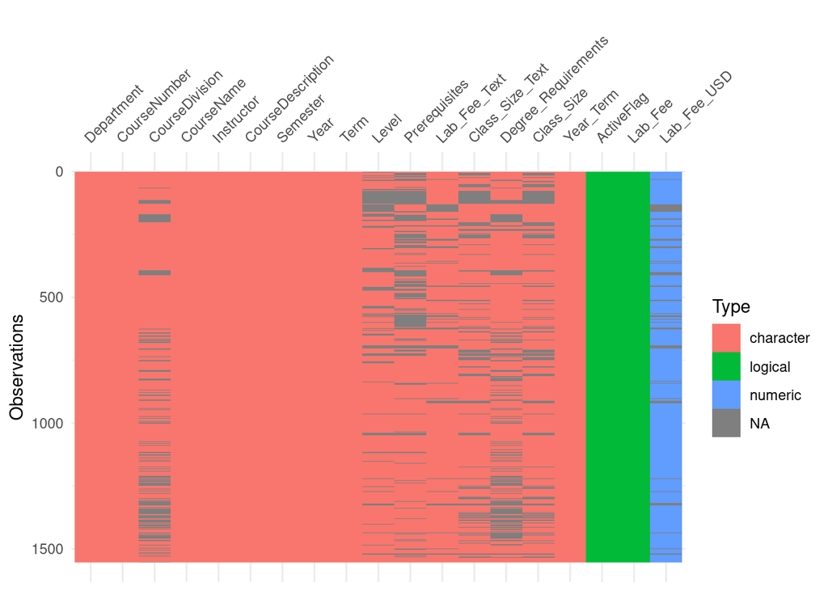

```r
visdat::vis_dat(coa_courses3)
```

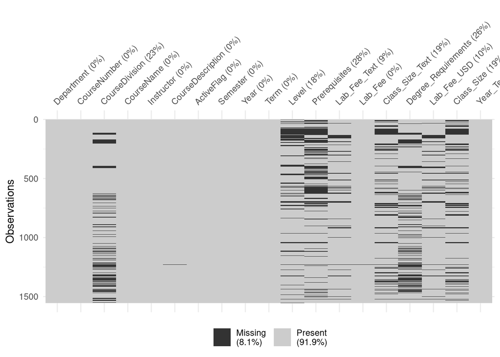

```r
visdat::vis_miss(coa_courses3)
```

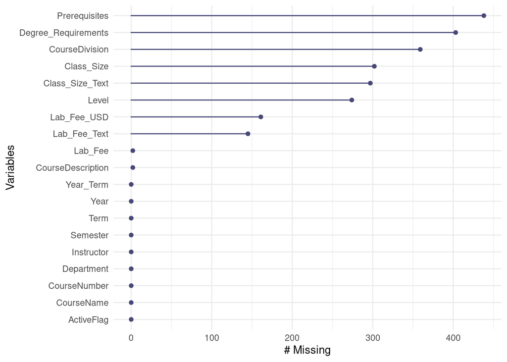

```r
naniar::gg_miss_var(coa_courses3)
```

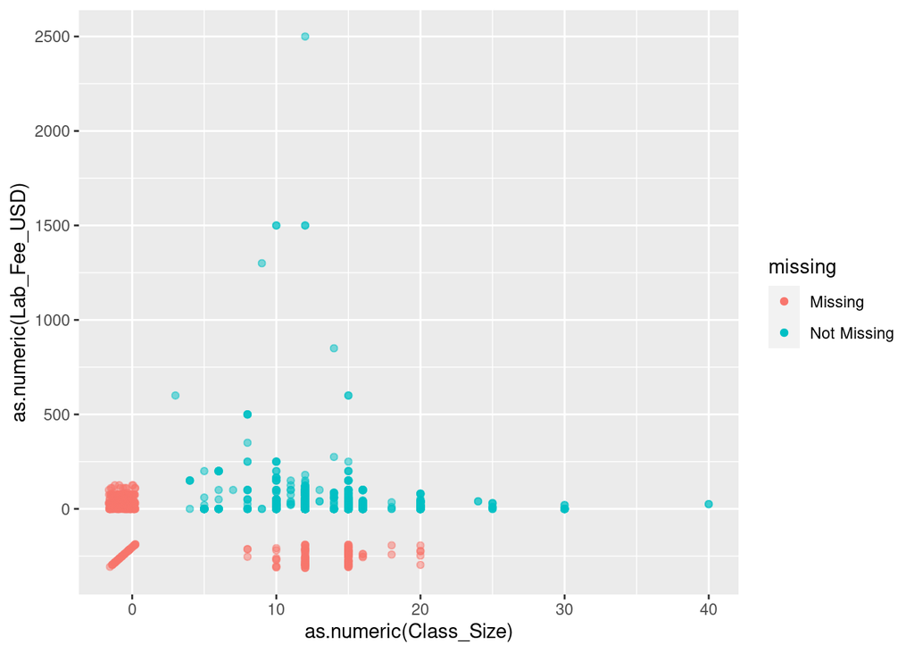

```r
ggplot(coa_courses3,
       aes(x = as.numeric(Class_Size),
           y = as.numeric(Lab_Fee_USD))) +
geom_miss_point(alpha = 0.5)
```

```r
instructors <- coa_courses2 %>% distinct(Instructor, Year)

instructors_distinct <- coa_courses2 %>% distinct(Instructor)

write_csv(instructors_distinct, file = "data/instructors.csv")

instructors <- instructors %>%
  mutate(instructor_status = case_when(Instructor %in% c("Anderson, John",
                                              "Andrews, Nancy",
                                              "Baker, Jodi",
                                              "Baker, Laurie",
                                              "Borden, Richard",
                                              "Carpenter, William",
                                              "Cline, Ken",
                                              "Clinger, Catherine",
                                              "Colbert, Dru",
                                              "Collum, Kourtney",
                                              "Cooper, John",
                                              "Cox, Gray",
                                              "Feldman, David",
                                              "Foley, Sean",
                                              "Friedlander, Jay",
                                              "Gatti, Daniel",
                                              "Hall, Sarah",
                                              "Henderson, Jonathan",
                                              "Hess, Helen",
                                              "Hill, Kenneth",
                                              "Hudson, Reuben",
                                              "Kozak, Anne",
                                              "Letcher, Susan",
                                              "Little-Siebold, Todd",
                                              "Mancinelli, Isabel",
                                              "McKown, Jamie",
                                              "Morse, Suzanne",
                                               "Petersen Christopher",
                                              "Ressel, Stephen",
                                              "Schrade, Daniel Kojo",
                                              "Stabinsky, Doreen",
                                              "Tai, Bonnie",
                                              "Taneja , Palak",
                                              "Tardif, Twila",
                                              "Taylor, Davis",
                                              "Todd, Sean",
                                               "van Vliet, Netta",
                                                "Visvader, John",
                                                "Waldron, Karen") ~ "Permanent Faculty",
                          Instructor %in% c("Pena, Karla") & Year <= 2022 ~ "Lecturer",
                          Instructor %in% c("Pena, Karla") & Year > 2022 ~ "Permanent Faculty",
                           Instructor %in% c("Lakey, Heather") & Year <= 2021 ~ "Adjunct",
                          Instructor %in% c("Lakey, Heather") & Year > 2021 ~ "Permanent Faculty",
                            Instructor %in% c("Soares, Zachary") & Year >= 2022 ~ "Teaching Staff",
                            Instructor %in% c("Soares, Zachary") & Year < 2022 ~ "Adjunct",
                            Instructor %in% c("Cass, Blake",
                                              "Fuller, Linda",
                                              "Gibson, David",
                                              "Teaching Staff",
                                              "Longsworth, Gordon") ~ "Teaching Staff",
                            Instructor %in% c("Beach, Desmond",
                                              "Chien, Ming-Tso",
                                              "Downing, E. Saffronia",
                                              "Oblongata, Donna") ~ "Visitor",
                           Instructor %in% c("Capers, Colin",
                                             "Donovan, Martha",
                                             "Levin, Robert",
                                             "Mahoney, Daniel",
                                              "Stover, Candice",
                                              "Swann, Scott",
                                              "Turok, Katharine",
                                              "Weber, Jill",
                                               "Winer, Joshua") ~ "Lecturer", TRUE ~ "Adjunct"))


coa_courses3 <- coa_courses3 %>%
  mutate(Year = as.numeric(Year)) %>%
left_join(instructors, by = c("Instructor", "Year"))
```

```r
coa_courses3$Lab_Fee_USD <- as.numeric(gsub("[^0-9.]", "", coa_courses3$Lab_Fee_USD))

coa_courses3$Lab_Fee_USD[is.na(coa_courses3$Lab_Fee_USD)] <- 0

print(coa_courses3)
```

```
## # A tibble: 1,554 × 20
##    Department CourseNumber CourseDivision CourseName                  Instructor
##    <chr>      <chr>        <chr>          <chr>                       <chr>
##  1 AD         1011         ADS            Introduction to Arts and D… Mancinell…
##  2 AD         1011         ADS            Introduction to Arts and D… Mancinell…
##  3 AD         1011         ADS            Introduction to Arts and D… Mancinell…
##  4 AD         1012         ADS            Introduction to Keyboard/P… Cooper, J…
##  5 AD         1012         ADS            Introduction to Keyboard/P… Cooper, J…
##  6 AD         1012         ADS            Introduction to Keyboard/P… Cooper, J…
##  7 AD         1013         AD HY          Jazz, Rock, and Blues:  Fr… Cooper, J…
##  8 AD         1013         AD HY          Jazz, Rock, and Blues:  Fr… Cooper, J…
##  9 AD         1013         AD HY          Jazz, Rock, and Blues:  Fr… Cooper, J…
## 10 AD         1013         AD HY          Jazz, Rock, and Blues:  Fr… Cooper, J…
## # ℹ 1,544 more rows
## # ℹ 15 more variables: CourseDescription <chr>, ActiveFlag <lgl>,
## #   Semester <chr>, Year <dbl>, Term <chr>, Level <chr>, Prerequisites <chr>,
## #   Lab_Fee_Text <chr>, Lab_Fee <lgl>, Class_Size_Text <chr>,
## #   Degree_Requirements <chr>, Lab_Fee_USD <dbl>, Class_Size <chr>,
## #   Year_Term <chr>, instructor_status <chr>
```

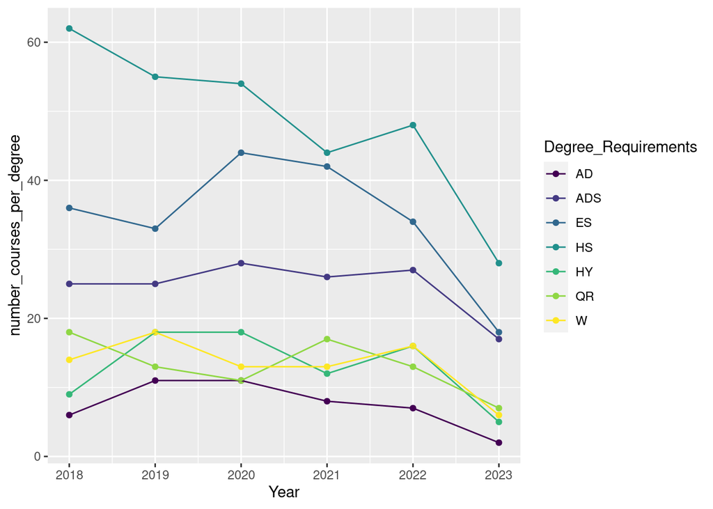

```r
coa_courses3 %>%
  filter(Degree_Requirements %in% c("ES", "ADS", "AD", "QR", "HS", "HY", "W")) %>%
  group_by(Year, Degree_Requirements) %>%
  summarize(number_courses_per_degree = n()) %>%
  ggplot(aes(x = Year, y = number_courses_per_degree, color = Degree_Requirements)) +
  geom_point() +
  geom_line(aes(group = Degree_Requirements)) +
  scale_colour_viridis_d()
```

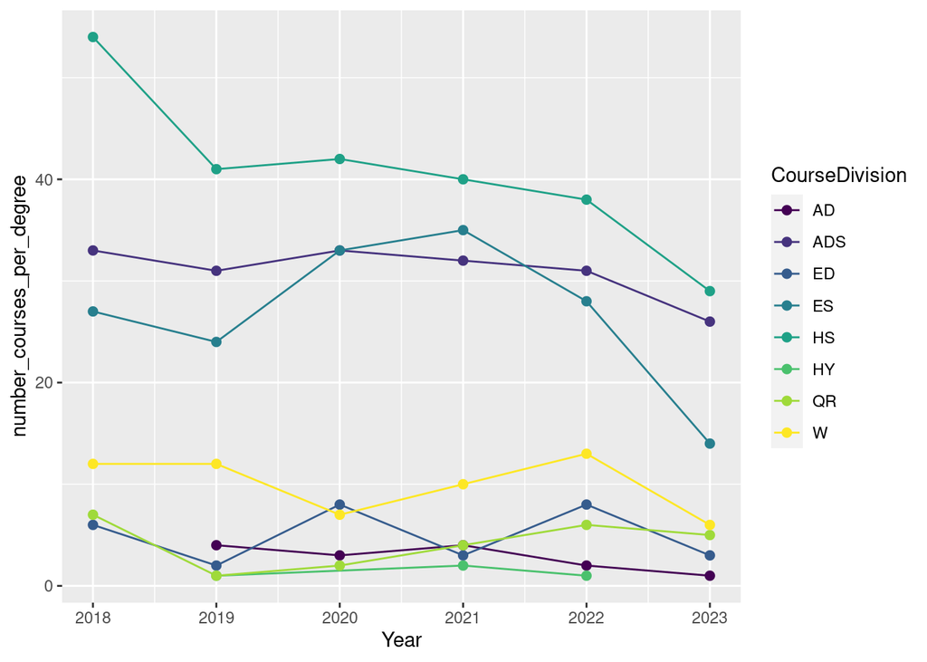

```r
coa_courses3 %>%
  filter(CourseDivision %in% c("ES", "ED", "ADS", "AD", "QR", "HS", "HY", "W")) %>%
  group_by(Year, CourseDivision) %>%
  summarize(number_courses_per_degree = n()) %>%
  ggplot(aes(x = Year, y = number_courses_per_degree, color = CourseDivision)) +
   geom_line(aes(group = CourseDivision)) +
  geom_point(size = 2) +
  scale_colour_viridis_d()
```

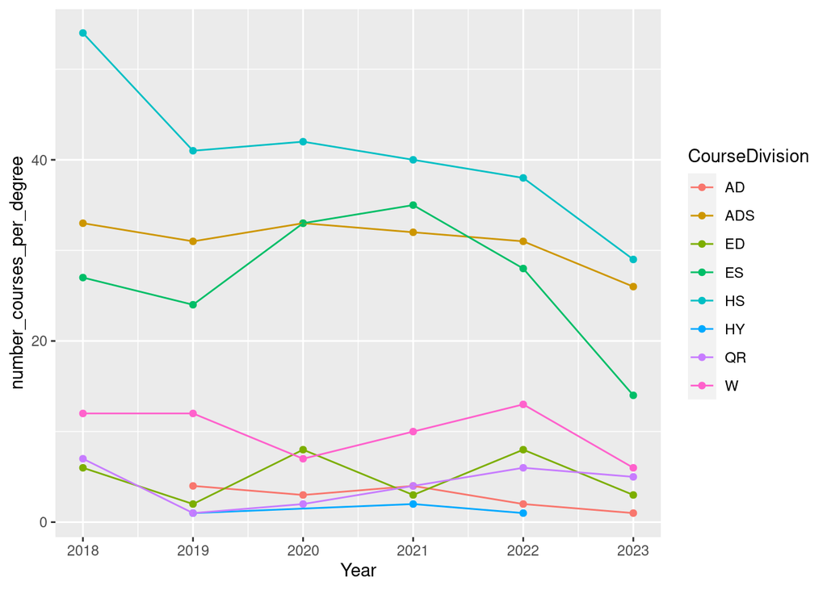

```r
coa_courses3 %>%
  filter(CourseDivision %in% c("ES", "ED", "ADS", "AD", "QR", "HS", "HY", "W")) %>%
  group_by(Year, CourseDivision) %>%
  summarize(number_courses_per_degree = n()) %>%
  ggplot(aes(x = Year, y = number_courses_per_degree, color = CourseDivision)) +
  geom_point() +
  geom_line(aes(group = CourseDivision))
```

```r
write_csv(coa_courses, file = "data/coa_courses2.csv")
```

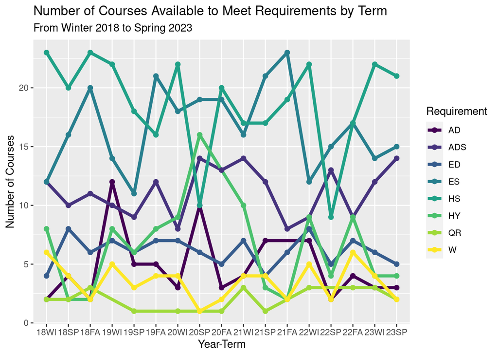

```r
coa_courses3$Year_Term <- as.factor(coa_courses3$Year_Term)

coa_courses3 %>%
  mutate(Requirement_opportunity = case_when(
    CourseDivision %in% c("AD", "AD HY", "AD HY WFO", "AD WFO") ~ "AD",
    CourseDivision %in% c("ADS", "ADS HY") ~ "ADS",
    CourseDivision %in% c("ED", "HS ED", "W ED") ~ "ED",
    CourseDivision %in% c("HY", "W HS HY", "W HY", "HS HY", "ES HY", "ADS HY", "AD HY WFO", "AD HY") ~ "HY",
    CourseDivision %in% c("HS", "HS ED", "HS HY", "HS QR", "HS WFO", "W HS", "W HS HY") ~ "HS",
    CourseDivision %in% c("ES", "ES HY", "ES QR", "W ES") ~ "ES",
    CourseDivision %in% c("QR", "ES QR", "HS QR") ~ "QR",
    CourseDivision %in% c("W", "W ED", "W ES", "W HS", "W HS HY", "W HY") ~ "W"
  )) %>%
  filter(!is.na(Requirement_opportunity)) %>%
  group_by(Year_Term, Requirement_opportunity) %>%
  summarize(count = n()) %>%
  ggplot(aes(x = fct_relevel(Year_Term,
                             c("18WI", "18SP", "18FA",
                               "19WI", "19SP", "19FA",
                               "20WI", "20SP", "20FA",
                               "21WI", "21SP", "21FA",
                               "22WI", "22SP", "22FA",
                               "23WI", "23SP")),
             y = count,
             color = Requirement_opportunity,
             group = Requirement_opportunity)) +
  geom_line(size = 1.5) +
  geom_point(size = 2) +
  labs(title = "Number of Courses Available to Meet Requirements by Term",
       subtitle = "From Winter 2018 to Spring 2023",
       x = "Year-Term",
       y = "Number of Courses",
       color = "Requirement") +
  scale_colour_viridis_d()
```

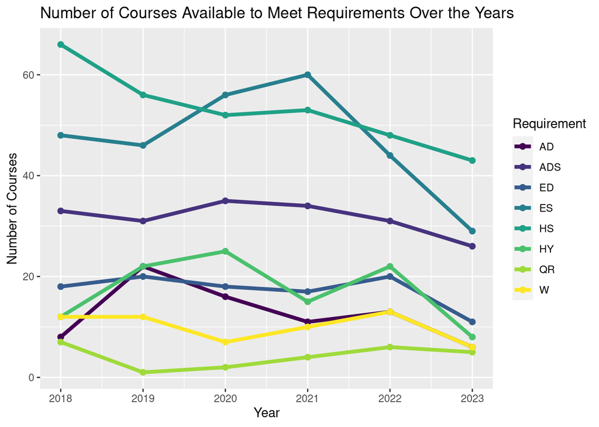

```r
coa_courses3 %>%
  mutate(Requirement_opportunity = case_when(
    CourseDivision %in% c("AD", "AD HY", "AD HY WFO", "AD WFO") ~ "AD",
    CourseDivision %in% c("ADS", "ADS HY") ~ "ADS",
    CourseDivision %in% c("ED", "HS ED", "W ED") ~ "ED",
    CourseDivision %in% c("HY", "W HS HY", "W HY", "HS HY", "ES HY", "ADS HY", "AD HY WFO", "AD HY") ~ "HY",
    CourseDivision %in% c("HS", "HS ED", "HS HY", "HS QR", "HS WFO", "W HS", "W HS HY") ~ "HS",
    CourseDivision %in% c("ES", "ES HY", "ES QR", "W ES") ~ "ES",
    CourseDivision %in% c("QR", "ES QR", "HS QR") ~ "QR",
    CourseDivision %in% c("W", "W ED", "W ES", "W HS", "W HS HY", "W HY") ~ "W"
  )) %>%
  filter(!is.na(Requirement_opportunity)) %>%
  group_by(Year, Requirement_opportunity) %>%
  summarize(count = n()) %>%
  ggplot(aes(x = Year,
             y = count,
             color = Requirement_opportunity,
             group = Requirement_opportunity)) +
  geom_line(size = 1.5) +
  geom_point(size = 2) +
  labs(title = "Number of Courses Available to Meet Requirements Over the Years",
       x = "Year",
       y = "Number of Courses",
       color = "Requirement") +
  scale_colour_viridis_d()
```

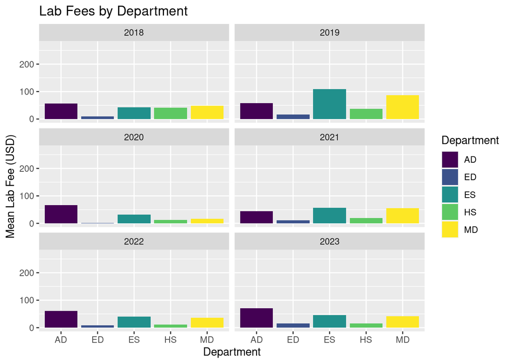

```r
coa_courses3 %>%
  filter(!Department %in% c('SG', 'GS', 'HE')) %>%
  ggplot(aes(x = Department, y = Lab_Fee_USD, fill = Department)) +
  geom_bar(stat = "summary", fun = "mean") +
  scale_fill_viridis_d() +
  labs(title = "Lab Fees by Department", x = "Department", y = "Mean Lab Fee (USD)") +
  facet_wrap(vars(Year), ncol = 2) +
  coord_cartesian(ylim = c(0, 270))
```

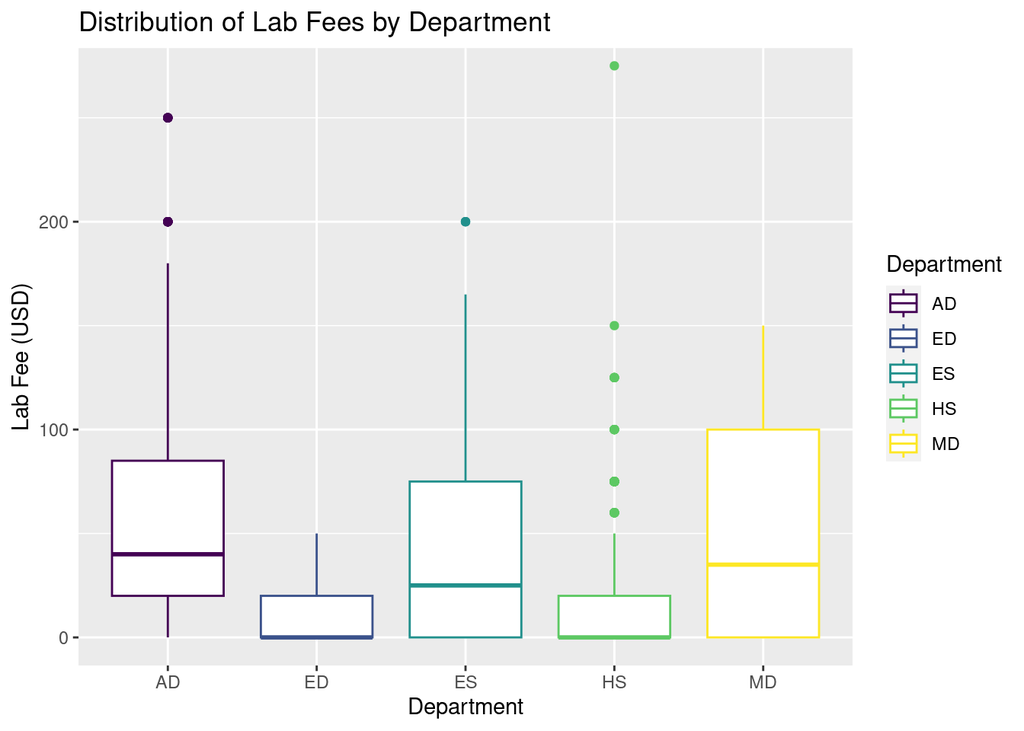

```r
coa_courses3 %>%
  filter(!Department %in% c('SG', 'GS', 'HE')) %>%
  ggplot(aes(x = Department, y = Lab_Fee_USD, colour = Department)) +
  geom_boxplot() +
  scale_colour_viridis_d() +
  labs(title = "Distribution of Lab Fees by Department", x = "Department", y = "Lab Fee (USD)") +
  coord_cartesian(ylim = c(0, 270))
```

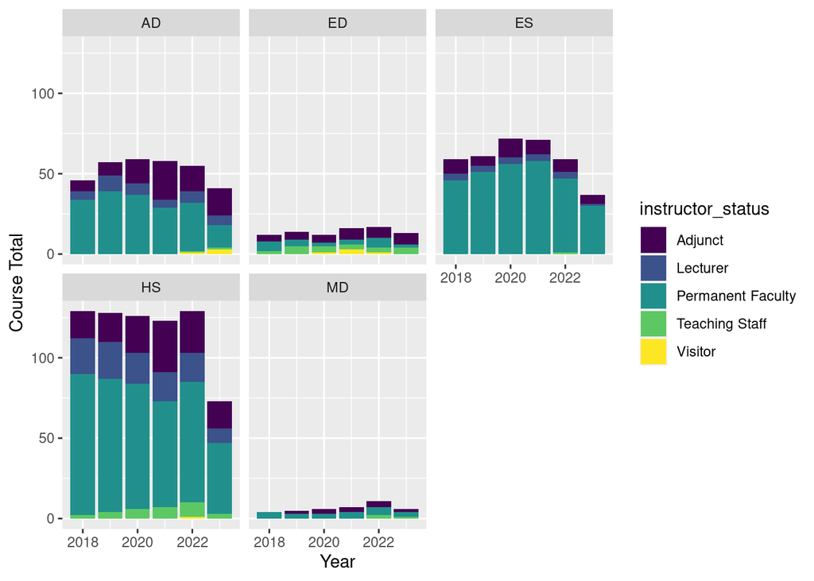

```r
coa_courses3 %>%
  group_by(Year, Department, instructor_status) %>%
  summarize(course_total = n()) %>%
  filter(!Department %in% c('HE', 'SG', 'GS')) %>%
  ggplot(aes(x = Year, y = course_total, fill = instructor_status)) +
  geom_col() +
  scale_fill_viridis_d() +
  facet_wrap(. ~ Department) +
  labs(y = "Course Total")
```

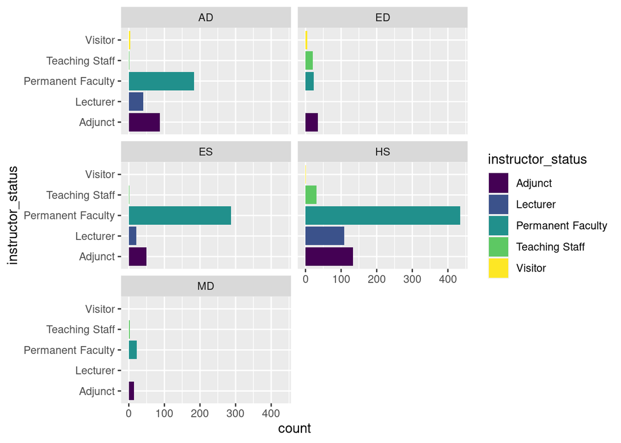

```r
coa_courses3 %>%
  filter(!Department %in% c('SG', 'GS', 'HE')) %>%
  ggplot() +
  geom_bar(aes(y = instructor_status, fill = instructor_status)) +
  facet_wrap(~ Department, ncol = 2) +
scale_fill_viridis_d()
```

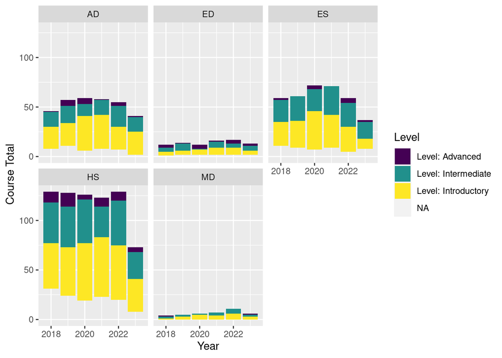

```r
coa_courses3 %>%
  group_by(Year, Department, Level) %>%
  summarize(course_total = n()) %>%
  filter(!Department %in% c('HE', 'SG', 'GS')) %>%
  ggplot(aes(x = Year, y = course_total, fill = Level)) +
  geom_col() +
  scale_fill_viridis_d() +
  facet_wrap(~Department) +
  labs(y = "Course Total")
```

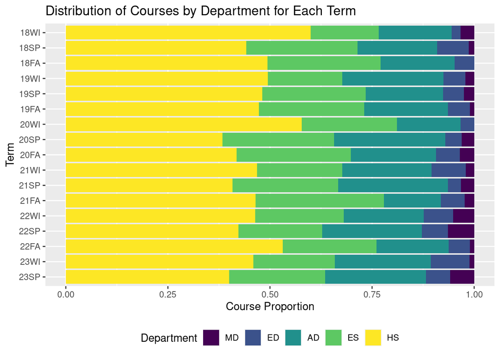

```r
P1 <- ggplot(subset(coa_courses3, Department != "SG" & Department != "GS" & Department != "HE"), aes(y = fct_rev(fct_relevel(Year_Term, c("18WI", "18SP",
        "18FA", "19WI", "19SP",
        "19FA", "20WI", "20SP",
        "20FA", "21WI", "21SP",
        "21FA", "22WI", "22SP",
        "22FA", "23WI", "23SP"))))) +
   scale_colour_viridis_d() +
  theme(legend.position = "bottom")

P1 +  geom_bar(aes(fill = fct_relevel(Department, c("MD", "ED","AD", "ES", "HS" ))), position = "fill") +
    labs(
    title = "Distribution of Courses by Department for Each Term",
    x = "Course Proportion",
    y = "Term",
  fill = "Department") +
  scale_fill_viridis_d()
```

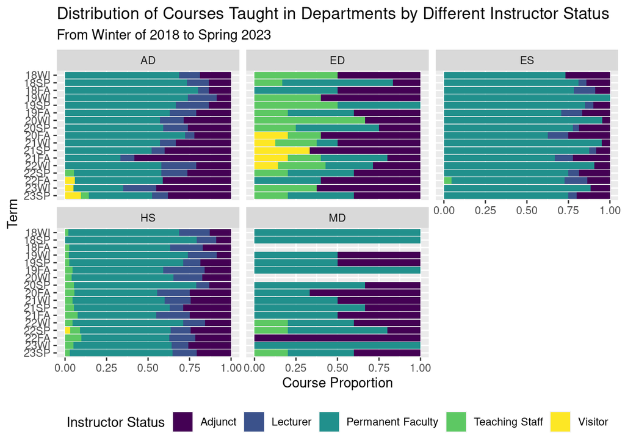

```r
P1 + facet_wrap(~ Department) +
  geom_bar(aes(fill = instructor_status),
           position = "fill") +
  labs(title = "Distribution of Courses Taught in Departments by Different Instructor Status",
  subtitle = "From Winter of 2018 to Spring 2023",
    x = "Course Proportion",
    y = "Term",
  fill = "Instructor Status") +
  scale_fill_viridis_d()
```

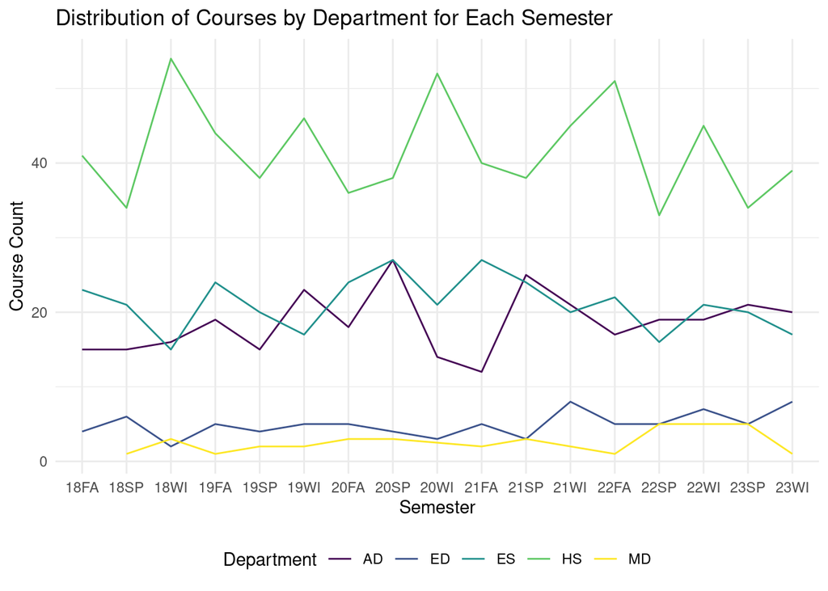

```r
ggplot(subset(coa_courses3, Department != "SG" & Department != "GS" & Department != "HE"), aes(x = Year_Term, y = after_stat(count), group = Department, color = Department)) +
  geom_line(stat = "count") +
  labs(
    title = "Distribution of Courses by Department for Each Semester",
    x = "Semester",
    y = "Course Count") +
  theme_minimal() +
  theme(legend.position = "bottom") +
  scale_colour_viridis_d()
```

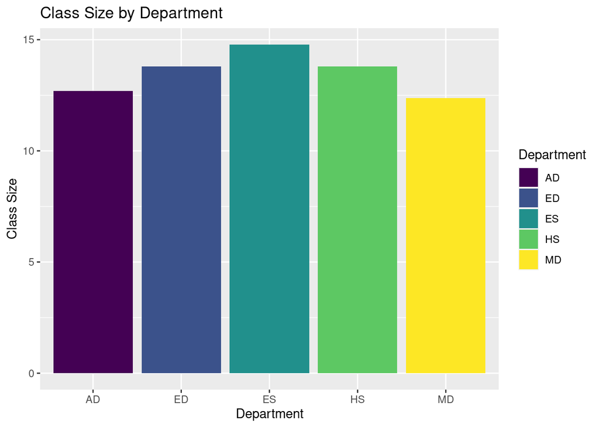

```r
coa_courses3$Class_Size <- as.numeric(gsub("[^0-9.]", "", coa_courses3$Class_Size))

ggplot(coa_courses3 %>% filter(!Department %in% c('HE', 'SG', 'GS')),
       aes(x = Department, y = Class_Size, fill = Department)) +
  geom_bar(stat = "summary", fun = "mean") +
  scale_fill_viridis_d() +
  labs(title = "Class Size by Department", x = "Department", y = "Class Size")
```

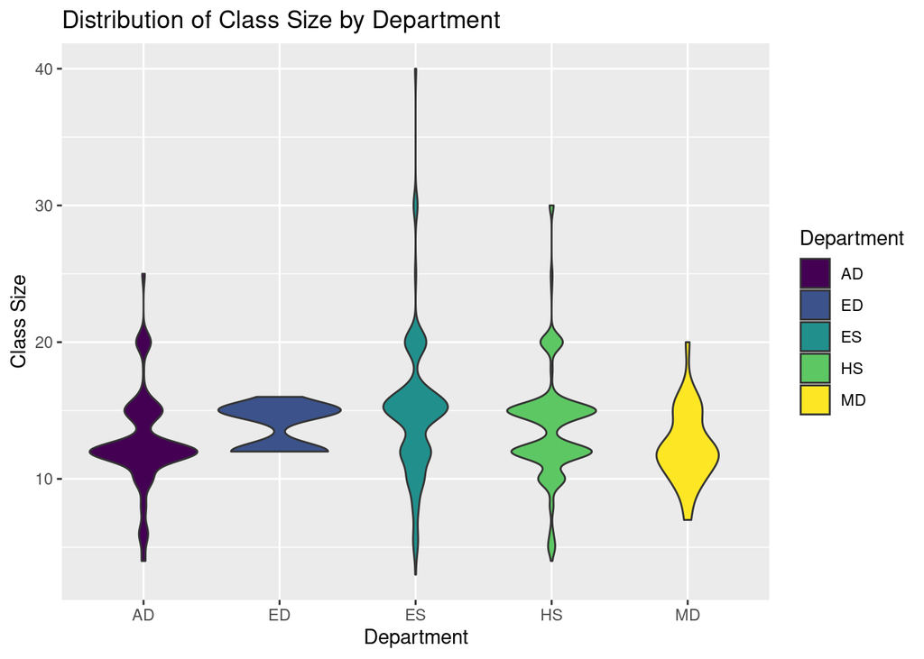

```r
ggplot(coa_courses3 %>%
         filter(!Department %in% c('HE', 'SG', 'GS')),
          aes(x = Department, y = Class_Size, fill = Department)) +
           geom_violin() +
          scale_fill_viridis_d() +
          labs(title = "Distribution of Class Size by Department",
               x = "Department", y = "Class Size")
```

## 1. Introduction

Every term during the registration period, the COA community navigates the system of academic courses categorized by resource area (department), course level, and the fulfillment of graduation requirements. These categories, which shape decisions on the system offering every term, are not as logical or functional as they could be. This situation has sparked a variety of interrelated research questions for this project. Our team will focus on the following questions:

- How are COA course offerings distributed across resource areas?
- How well are COA course offerings meeting students’ graduation requirement needs?
- How many courses are permanent and visiting faculty teaching, proportionally?
- What are the Lab fees in the different resource areas?
- How does class size vary among resource areas?

## 2. Data

- [Yes] Is the data in the /data folder?
- [Yes] Does the README include the dimensions and codebook for the data set?
- [Yes] Does the proposal include the output of glimpse() or skim() of the data frame.

## 3. Ethics review

On our coa_courses3 dataset, some variables (columns) have an N/A or blank space. These data shortcomings might limit the accuracy of our data visualizations and summaries. The variables missing data are Level, Prerequisites, Lab_fee_USD, Class_Size, and Degree_Requirements. Since students make up our team, we will continue verifying information and our interpretations of the data with Laurie, Krystal, Lothar, and Jamie McKown. Additionally, our team will aim to communicate any limitations on the visualizations and their accompanying texts when appropriate.

Moreover, our team anticipates that the Academic Affairs Committee (AAC) and the COA community will benefit from our work in future decision-making. As our college evolves, various stakeholders need to figure out how to address the course-offering system’s shortcomings and strengths to best cater to the needs of the student body and the work capacity of our faculty. Our efforts will likely be the first step in an in-depth data analysis of trends and possibilities that we hope are expanded by future students to answer our questions and new ones that arise more accurately.

## 4. Data analysis plan

We will create a visualization showing course distribution in their respective resource areas throughout the years/ terms. We will also create visualizations to show how many classes meet degree requirements per resource area. Additionally we will make note of how many professors are teaching classes that meet degree requirements per term.

We might possibly extend or reorganize the current dataset in groupings that include the status of each instructor, visiting faculty, faculty, lecturer, teaching staff and so on. This information will be provided by Krystal, the Registrar, and Lothar, Academic Services Administrator.

## 5. Unfinished code to continue with.